# Homework 2

```python
import torch

print("PyTorch:", torch.__version__)
print("CUDA runtime:", torch.version.cuda)
print("GPU available:", torch.cuda.is_available())

if torch.cuda.is_available():
    print("GPU:", torch.cuda.get_device_name(0))
```

```
PyTorch: 2.14.1+cu126
CUDA runtime: 12.6
GPU available: True
GPU: NVIDIA A100-SXM4-40GB
```

```python
device = torch.device("cuda" if torch.cuda.is_available() else "cpu")
```

```python
import copy
import librosa
import numpy as np
import matplotlib.pyplot as plt

from IPython.display import Audio, display
import soundfile as sf

import torch.nn as nn
from torch.utils.data import TensorDataset, DataLoader
```

# Question 1

## Speech denoising using a DNN

In this problem, I train a fully connected DNN to reduce unwanted noise in a speech recording. The model takes the magnitude specturm of noisy speech as an input, and predicts an estimate of the corresponding clean speech magnitude

The audio is originally represented as a 1d waveform in the time domain, so I first apply a STFT to get the time frequency representation. The predicted magnitudes are then combined with the phase of the original noisy recording and then tranformed back into a wavform using a inverse STFT

```python
clean, sr = librosa.load("data/train_clean_male.wav", sr=None)
noisy, sr_noisy = librosa.load("data/train_dirty_male.wav", sr=None)

print("Clean shape:", clean.shape)
print("Noisy shape:", noisy.shape)
print("Sample rate:", sr)
print("Duration:", len(clean) / sr, "seconds")
```

```
Clean shape: (1258899,)
Noisy shape: (1258899,)
Sample rate: 16000
Duration: 78.6811875 seconds
```

```python
val_noisy, sr_val = librosa.load("data/test_x_01.wav", sr=None)
val_clean, sr_clean = librosa.load("data/test_s_01.wav", sr=None)

print(sr_val == sr_clean == sr)

X_val = librosa.stft(val_noisy, n_fft=1024, hop_length=512)
print("Validation STFT shape:", X_val.shape)
```

```
True
Validation STFT shape: (513, 142)
```

```python
print("Clean speech:")
display(Audio(clean, rate=sr))

print("Noisy speech:")
display(Audio(noisy, rate=sr_noisy))
```

```
Clean speech:
```

[interactive chart not shown]

```
Noisy speech:
```

[interactive chart not shown]

```python
S = librosa.stft(clean, n_fft=1024, hop_length=512)
X = librosa.stft(noisy, n_fft=1024, hop_length=512)

print("Clean spectrogram shape:", S.shape)
print("Noisy spectrogram shape:", X.shape)
```

```
Clean spectrogram shape: (513, 2459)
Noisy spectrogram shape: (513, 2459)
```

```python
S_mag = np.abs(S)
X_mag = np.abs(X)

print(S_mag.shape)
print(X_mag.shape)

X_train = X_mag.T # transposing to get training examples by features (frequency magnitudes)
Y_train = S_mag.T

print(X_train.shape)
print(Y_train.shape)
```

```
(513, 2459)
(513, 2459)
(2459, 513)
(2459, 513)
```

### STFT Representation

The STFT represents a waveform in terms of frequency content over time. This gives complex valued coefficients that have both magnitude and phase. For training, I extract just the magnitudes using np.abs(). The resulting magnitude arrays then need to be transposed so that each row represents a single time frame with 513 frequency magnitudes.

```python
scale = X_train.std()

X_train_scaled = X_train / scale # not subracting by mean because we need to preserve non negatives
Y_train_scaled = Y_train / scale

print("Scale factor:", scale)
print("Scaled input mean:", X_train_scaled.mean())
print("Scaled input std:", X_train_scaled.std())
print("Scaled target mean:", Y_train_scaled.mean())
```

```
Scale factor: 0.3290241
Scaled input mean: 0.34561062
Scaled input std: 1.0
Scaled target mean: 0.20520827
```

### Normalization

Before I train, the noisy and clean STFT magnitudes are normalized using the standard deviation of the noisy train magnitudes

$$ \sigma_X=\operatorname{std}(X_{\text{train}}) $$

$$ \widetilde{X}=\frac{X_{\text{train}}}{\sigma_X}, \qquad \widetilde{S}=\frac{S_{\text{train}}}{\sigma_X} $$

The same scaling factor is given to both iputs and targets so they remain consistent in unites. I intentionally did not apply conventional standardizeation, as that would produce negative values. Instead I did not subtract by the mean to make sure I only hav non negative magnitudes

During validation and testing, predictions are converted back to the original scale by multiplying $\sigma_X$:

$$ \widehat{S}=\sigma_X\widehat{\widetilde{S}} $$

```python
def reconstruct_audio(predicted_mag, noisy_stft, length):
    phase = noisy_stft / (np.abs(noisy_stft) + 1e-10)
    reconstructed_stft = predicted_mag * phase
    reconstructed_audio = librosa.istft(reconstructed_stft, hop_length=512, length=length)
    return reconstructed_audio
```

```python
reconstructed_noisy = reconstruct_audio(
    predicted_mag=np.abs(X_val),
    noisy_stft=X_val,
    length=len(val_noisy)
)

print("Original shape:", val_noisy.shape)
print("Reconstructed shape:", reconstructed_noisy.shape)

print(
    "Reconstruction MSE:",
    np.mean((val_noisy - reconstructed_noisy) ** 2)
)
```

```
Original shape: (72619,)
Reconstructed shape: (72619,)
Reconstruction MSE: 7.335114e-18
```

```python
class MaskingDenoiser(nn.Module):
    def __init__(self):
        super().__init__()

        self.network = nn.Sequential(
            nn.Linear(513, 1024),
            nn.LeakyReLU(negative_slope=0.01),

            nn.Linear(1024, 512),
            nn.LeakyReLU(negative_slope=0.01),

            nn.Linear(512, 513),
            nn.Sigmoid()
        )

    def forward(self, x):
        mask = self.network(x)
        return mask * x
```

### DNN Architecture and Spectral Masking

When I first attacked this problem, I initally tried a basic CNN with no spectral masking, predicting clean spectral magnitudes directly from the noisy ones. This approach produced very poor validation performace (~8 SNR), much worse than the baseline SNR of 13

Instead of predicting the clean magnitudes directly, this model learns a multiplicative mask saying how much of each noisy frequency magnitude should be retained. This improved the performance by nearly a magnitude of 2

A mask value close to 1 perserves most of the original magnitude, and a value of 0 supresses it. During training the network learns which frequencies to perserve or suppress by minimizng the difference between the estimaged and clean spectral magnitudes.

Final DNN architecture

- Input layer: 513 noisy STFT magnitudes
- First hidden layer: 1024 neurons with LeakyReLU activation
- Seoond hidden layer: 512 Nuerons with LeakyReLU activation
- Output layer: 513 neruoens with sigmoid activation (which produces the spectral mask)

```python
def calculate_snr(clean, reconstructed):
    signal_energy = np.sum(clean ** 2)
    error_energy = np.sum((clean - reconstructed) ** 2)

    snr = 10 * np.log10(
        (signal_energy + 1e-20) / (error_energy + 1e-20)
    )

    return snr
```

```python
print("Clean samples:", len(val_clean))
print("Noisy samples:", len(val_noisy))

baseline_snr = calculate_snr(val_clean, val_noisy)

print(f"Baseline noisy SNR: {baseline_snr:.2f} dB")
```

```
Clean samples: 72619
Noisy samples: 72619
Baseline noisy SNR: 13.23 dB
```

```python
def validate_model(model, X_val, val_clean, val_noisy, scale, device):
    model.eval()

    X_val_mag = np.abs(X_val)
    X_val_scaled = X_val_mag.T / scale

    X_val_tensor = torch.tensor(
        X_val_scaled,
        dtype=torch.float32,
        device=device
    )

    with torch.no_grad():
        predicted_scaled = model(X_val_tensor)

    predicted_mag = predicted_scaled.cpu().numpy().T * scale
    reconstructed = reconstruct_audio(predicted_mag, X_val, length=len(val_noisy))
    snr = calculate_snr(val_clean, reconstructed)

    return snr
```

```python
X_tensor = torch.tensor(X_train_scaled, dtype=torch.float32)
Y_tensor = torch.tensor(Y_train_scaled, dtype=torch.float32)

train_dataset = TensorDataset(X_tensor, Y_tensor)

train_loader = DataLoader(
    train_dataset,
    batch_size=32,
    shuffle=True
)
```

```python
torch.manual_seed(42)

model = MaskingDenoiser().to(device)
optimizer = torch.optim.Adam(model.parameters(), lr=0.001)

criterion = nn.MSELoss()
```

```python
num_epochs = 200
patience = 25

best_snr = float("-inf")
best_weights = None
best_epoch = 0
epochs_without_impovement = 0

train_losses = []
val_snrs = []

for epoch in range(num_epochs):
    model.train()
    total_loss = 0.0

    for noisy_batch, clean_batch in train_loader:
        noisy_batch = noisy_batch.to(device)
        clean_batch = clean_batch.to(device)

        optimizer.zero_grad()

        predictions = model(noisy_batch)
        loss = criterion(predictions, clean_batch)

        loss.backward()
        optimizer.step()

        total_loss += loss.item() * noisy_batch.size(0)

    avg_loss = total_loss / len(train_dataset)
    train_losses.append(avg_loss)

    val_snr = validate_model(model, X_val, val_clean, val_noisy, scale, device)
    val_snrs.append(val_snr)

    if val_snr > best_snr:
        best_snr = val_snr
        best_epoch = epoch + 1
        best_weights = copy.deepcopy(model.state_dict())
        epochs_without_impovement = 0
    else:
        epochs_without_impovement += 1

    if (epoch + 1) % 5 == 0 or epoch == 0:
        print(
            f"Epoch {epoch+1:3d} | "
            f"Train MSE: {avg_loss:.5f} | "
            f"Validation SNR: {val_snr:.2f} dB | "
            f"Best: {best_snr:.2f} dB"
        )

    if epochs_without_impovement >= patience:
        print(f"\nEarly stopping at epoch {epoch + 1}")
        break

model.load_state_dict(best_weights)

print(f"\nBest epoch: {best_epoch}")
print(f"Best validation SNR: {best_snr:.2f} dB")
print(f"Imporovement over baseline: {best_snr - baseline_snr:.2f} dB")
```

```
Epoch   1 | Train MSE: 0.05112 | Validation SNR: 14.19 dB | Best: 14.19 dB
Epoch   5 | Train MSE: 0.01772 | Validation SNR: 14.09 dB | Best: 14.19 dB
```

```
Epoch  10 | Train MSE: 0.01795 | Validation SNR: 13.48 dB | Best: 14.79 dB
Epoch  15 | Train MSE: 0.01080 | Validation SNR: 14.91 dB | Best: 15.38 dB
Epoch  20 | Train MSE: 0.00926 | Validation SNR: 15.98 dB | Best: 15.98 dB
Epoch  25 | Train MSE: 0.00761 | Validation SNR: 16.10 dB | Best: 16.95 dB
Epoch  30 | Train MSE: 0.00669 | Validation SNR: 16.51 dB | Best: 16.95 dB
Epoch  35 | Train MSE: 0.00612 | Validation SNR: 14.47 dB | Best: 16.95 dB
Epoch  40 | Train MSE: 0.00518 | Validation SNR: 15.02 dB | Best: 16.95 dB
Epoch  45 | Train MSE: 0.00504 | Validation SNR: 13.12 dB | Best: 16.95 dB

Early stopping at epoch 47

Best epoch: 22
Best validation SNR: 16.95 dB
Imporovement over baseline: 3.73 dB
```

### Training and Valdiation

The model was trained using MSE between the predicted normalized clean magnitudes and the corresponding clean training magnitudes. Training ued the Adam optimzer with a learning rate of 0.001 and a mini batch size of 32.

Validatioan performance was measured using signal to noise ratio in the time domain

$$ \operatorname{SNR}{dB}=10\log{10} \left( \frac{\sum_n s[n]^2} {\sum_n(s[n]-\widehat{s}[n])^2} \right) $$

Higher SNR means the reconstructed waveform contains less error relative to the clean reference

Validation SNR was evaluated after every epoch. Early stopping with patience of 25 was used to prevent unnecessary training after validation performance stopped improving. Thee model weights corresponding to the highest validation SNR was restored and saved for the final evaluation.

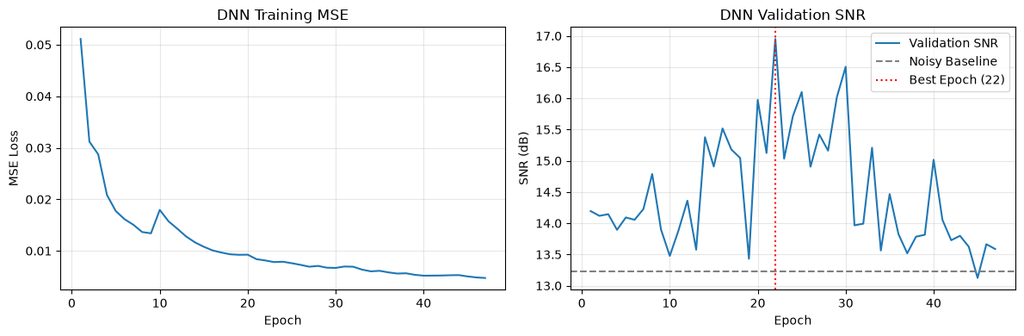

```python
epochs = np.arange(1, len(train_losses) + 1)

fig, axes = plt.subplots(1, 2, figsize=(12, 4))

axes[0].plot(epochs, train_losses)
axes[0].set_title("DNN Training MSE")
axes[0].set_xlabel("Epoch")
axes[0].set_ylabel("MSE Loss")
axes[0].grid(alpha=0.3)

axes[1].plot(epochs, val_snrs, label="Validation SNR")
axes[1].axhline(
    baseline_snr, linestyle="--", color="gray",
    label="Noisy Baseline"
)
axes[1].axvline(
    best_epoch, linestyle=":", color="red",
    label=f"Best Epoch ({best_epoch})"
)
axes[1].set_title("DNN Validation SNR")
axes[1].set_xlabel("Epoch")
axes[1].set_ylabel("SNR (dB)")
axes[1].legend()
axes[1].grid(alpha=0.3)

plt.tight_layout()
plt.show()
```

```python
torch.save(best_weights, "best_model.pt")
```

```python
model.eval()

with torch.no_grad():
    X_val_input = torch.tensor(
        np.abs(X_val).T / scale,
        dtype=torch.float32,
        device=device
    )

    predicted_mag = model(X_val_input).cpu().numpy().T * scale

denoised_val = reconstruct_audio(
    predicted_mag,
    X_val,
    length=len(val_noisy)
)

from IPython.display import Audio, display

print("Original noisy validation speech:")
display(Audio(val_noisy, rate=sr_val))

print("Denoised validation speech:")
display(Audio(denoised_val, rate=sr_val))
```

```
Original noisy validation speech:
```

[interactive chart not shown]

```
Denoised validation speech:
```

[interactive chart not shown]

### Testing test_02_x.wav

```python
test_noisy, sr_test = librosa.load("data/test_x_02.wav", sr=None)

print("Sample rate:", sr_test)
print("Duration:", len(test_noisy) / sr_test, "seconds")

display(Audio(test_noisy, rate=sr_test))
```

```
Sample rate: 16000
Duration: 12.1470625 seconds
```

[interactive chart not shown]

```python
model = MaskingDenoiser().to(device)

model.load_state_dict(
    torch.load("best_model.pt", map_location=device, weights_only=True)
)

model.eval()

X_test = librosa.stft(
    test_noisy,
    n_fft=1024,
    hop_length=512
)

X_test_scaled = np.abs(X_test).T / scale

X_test_tensor = torch.tensor(
    X_test_scaled,
    dtype=torch.float32,
    device=device
)

with torch.no_grad():
    predicted_scaled = model(X_test_tensor)

predicted_mag = predicted_scaled.cpu().numpy().T * scale

denoised_test = reconstruct_audio(
    predicted_mag,
    X_test,
    length=len(test_noisy)
)
```

```python
print("Original recording:")
display(Audio(test_noisy, rate=sr_test))

print("Denoised recording:")
display(Audio(denoised_test, rate=sr_test))
```

```
Original recording:
```

[interactive chart not shown]

```
Denoised recording:
```

[interactive chart not shown]

```python
sf.write("test_02_denoised.wav", denoised_test, sr_test)
```

# Question 2

## Speech denoising with a 1d CNN

In this problem, I used a 1d CNN to denoise the same speech recordings from problem 1. The STFT preprocessing, magnitude normalization, spectral masking, training loss, validaton SNR calculation, and audio reconstruction remain unchaged.

The CNN applied convolutional kernels across neighboring frequency bins. The kernels learn local patterns in the frequency spectrum that help distinguish speech from noise

The final CNN architecture consists of:

- First convolution: 64 output channels, kernel size of 9, stride 2, and GELU activation
- Max pooling: Kernel size 2, stride 2
- Second Convolution: 128 output channels, the rest the same as the first
- Flatten: Converts the final convolutional feature maps into a single feature vector per example.
- Fully connected layer: Maps the flattened features to 513 outputs
- Sigmoid activation: Generates a spectral mask between 0 and 1

```python
class CNNDenoiserPool(nn.Module):
    def __init__(self):
        super().__init__()
        self.network = nn.Sequential(
            nn.Conv1d(1, 64, kernel_size=9, stride=2),
            nn.GELU(),

            nn.MaxPool1d(kernel_size=2),

            nn.Conv1d(64, 128, kernel_size=9, stride=2),
            nn.GELU(),

            nn.Flatten(),

            nn.Linear(7552, 513),
            nn.Sigmoid()
        )

    def forward(self, x):
        mask = self.network(x)
        return mask * x.squeeze(1)
```

### Convolutional output dimensions

Because the convolutional layers operate across the frequency dimension without zero padding, the output length of each layer can be calculated using $$ L_{\text{out}}=\left\lfloor\frac{L_{\text{in}}+2P-K}{S}\right\rfloor+1 $$

where $L_{\text{in}}$ is the input length, $K$ is kernel size, $S$ is stride, and $P$ is padding. In this implementation, $P=0$ for both convolutional layers.

```python
def validate_cnn(model, X_val, val_clean, val_noisy, scale, device):
    model.eval()

    X_val_mag = np.abs(X_val)
    X_val_scaled = X_val_mag.T / scale

    X_val_tensor = torch.tensor(
        X_val_scaled,
        dtype=torch.float32,
        device=device
    ).unsqueeze(1)

    with torch.no_grad():
        predicted_scaled = model(X_val_tensor)

    predicted_mag = predicted_scaled.cpu().numpy().T * scale
    reconstructed = reconstruct_audio(predicted_mag, X_val, length=len(val_noisy))
    snr = calculate_snr(val_clean, reconstructed)

    return snr
```

```python
X_cnn = torch.tensor(
    X_train_scaled,
    dtype=torch.float32
).unsqueeze(1)

Y_cnn = torch.tensor(
    Y_train_scaled,
    dtype=torch.float32
)

cnn_dataset = TensorDataset(X_cnn, Y_cnn)

cnn_loader = DataLoader(
    cnn_dataset,
    batch_size=32,
    shuffle=True
)
```

```python
torch.manual_seed(42)

cnn_model = CNNDenoiserPool().to(device)

cnn_optimizer = torch.optim.Adam(
    cnn_model.parameters(),
    lr = 0.001
)

cnn_criterion = nn.MSELoss()
```

```python
num_epochs = 200
patience = 25

best_snr = float("-inf")
best_cnn_weights = None
best_epoch = 0
epochs_without_impovement = 0

train_losses = []
val_snrs = []

for epoch in range(num_epochs):
    cnn_model.train()
    total_loss = 0.0

    for noisy_batch, clean_batch in cnn_loader:
        noisy_batch = noisy_batch.to(device)
        clean_batch = clean_batch.to(device)

        cnn_optimizer.zero_grad()

        predictions = cnn_model(noisy_batch)
        cnn_loss = cnn_criterion(predictions, clean_batch)

        cnn_loss.backward()
        cnn_optimizer.step()

        total_loss += cnn_loss.item() * noisy_batch.size(0)

    avg_loss = total_loss / len(cnn_dataset)
    train_losses.append(avg_loss)

    val_snr = validate_cnn(cnn_model, X_val, val_clean, val_noisy, scale, device)
    val_snrs.append(val_snr)

    if val_snr > best_snr:
        best_snr = val_snr
        best_epoch = epoch + 1
        best_cnn_weights = copy.deepcopy(cnn_model.state_dict())
        epochs_without_impovement = 0
    else:
        epochs_without_impovement += 1

    if (epoch + 1) % 5 == 0 or epoch == 0:
        print(
            f"Epoch {epoch+1:3d} | "
            f"Train MSE: {avg_loss:.5f} | "
            f"Validation SNR: {val_snr:.2f} dB | "
            f"Best: {best_snr:.2f} dB"
        )

    if epochs_without_impovement >= patience:
        print(f"\nEarly stopping at epoch {epoch + 1}")
        break

cnn_model.load_state_dict(best_cnn_weights)

print(f"\nBest epoch: {best_epoch}")
print(f"Best validation SNR: {best_snr:.2f} dB")
print(f"Imporovement over baseline: {best_snr - baseline_snr:.2f} dB")
```

```
Epoch   1 | Train MSE: 0.03521 | Validation SNR: 14.43 dB | Best: 14.43 dB
```

```
Epoch   5 | Train MSE: 0.01254 | Validation SNR: 15.26 dB | Best: 15.96 dB
Epoch  10 | Train MSE: 0.00881 | Validation SNR: 14.81 dB | Best: 15.96 dB
Epoch  15 | Train MSE: 0.00806 | Validation SNR: 13.45 dB | Best: 15.96 dB
Epoch  20 | Train MSE: 0.00641 | Validation SNR: 14.51 dB | Best: 15.96 dB
Epoch  25 | Train MSE: 0.00601 | Validation SNR: 14.15 dB | Best: 15.96 dB

Early stopping at epoch 29

Best epoch: 4
Best validation SNR: 15.96 dB
Imporovement over baseline: 2.74 dB
```

```python
torch.save(best_cnn_weights, "best_cnn_weights.pt")
```

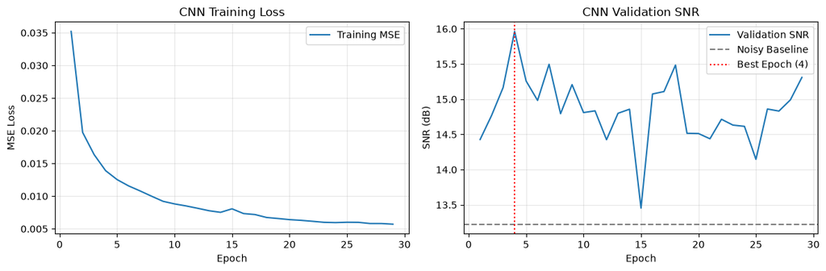

```python
epochs = np.arange(1, len(train_losses) + 1)

fig, axes = plt.subplots(1, 2, figsize=(12, 4))

# Training loss
axes[0].plot(epochs, train_losses, label="Training MSE")
axes[0].set_xlabel("Epoch")
axes[0].set_ylabel("MSE Loss")
axes[0].set_title("CNN Training Loss")
axes[0].legend()
axes[0].grid(True, alpha=0.3)

# Validation SNR
axes[1].plot(epochs, val_snrs, label="Validation SNR")
axes[1].axhline(
    baseline_snr,
    linestyle="--",
    color="gray",
    label="Noisy Baseline"
)
axes[1].axvline(
    best_epoch,
    linestyle=":",
    color="red",
    label=f"Best Epoch ({best_epoch})"
)
axes[1].set_xlabel("Epoch")
axes[1].set_ylabel("SNR (dB)")
axes[1].set_title("CNN Validation SNR")
axes[1].legend()
axes[1].grid(True, alpha=0.3)

plt.tight_layout()
plt.show()
```

### Results and comparison with Problem 1

The CNN was trained using the same MSE loss and Adam optimzer as the DNN in problem 1. Validation SNR was calculated after every epoch, early stopping was used to select the best performing model

I tested several configurations, including different channel counts, kernel sizes, activation functions, and pooling strategies. The selected architecture used 64 and 128 convolutional channels, a kernel size of 9, GELU activation and max pooling.

The best CNN achieved a validation SNR of 15.96, compared with the baseline 13.23 dB for the orignal noisy audio, this gave an improvement of about 2.75 DB

The CNN did reduce noise, it did not outperform the fully connected DNN from problem 1, which achieved a SNR of 16.95 dB. One possible explination is that the DNN fully connected layers could use information from all frequency bins immedialty, where the CNN initially learns local frequency patterns and compresses the representation through pooling

```python
X_test_cnn = librosa.stft(test_noisy, n_fft=1024, hop_length=512)


X_test_tensor_cnn = torch.tensor(
    np.abs(X_test_cnn).T / scale,
    dtype=torch.float32,
    device=device
).unsqueeze(1)

cnn_model.eval()

with torch.no_grad():
    predicted_scaled = cnn_model(X_test_tensor_cnn)

predicted_mag = predicted_scaled.cpu().numpy().T * scale

cnn_denoised = reconstruct_audio(
    predicted_mag,
    X_test,
    length=len(test_noisy)
)

sf.write("test_02_cnn_denoised.wav", cnn_denoised, sr_test)
```

```python
print("Original recording:")
display(Audio(test_noisy, rate=sr_test))

print("CNN Denoised:")
display(Audio(cnn_denoised, rate=sr_test))
```

```
Original recording:
```

[interactive chart not shown]

```
CNN Denoised:
```

[interactive chart not shown]

# Question 3 CIFAR-10 Image Classification

In this problem, I trained a 2d CNN to classify images from the CIFAR 10 dataset into 10 object categories. The dataset has 50,000 32 x 32 training images. I used 5,000 images for validation and the remaining for training

Pixel values are converted from the original range $[0,255]$ to $[-1,1]$ using:

$$ x_{\text{scaled}}=2\left(\frac{x}{255}\right)-1 $$

The CNN uses the architecture specified in the assignment, with ReLU activations, He weight initialization, and no zero-padding.

```python
from torchvision.datasets import CIFAR10

dataset = CIFAR10(root="./data", train=True, download=True)

print("Number of images:", len(dataset))
```

```
Number of images: 50000
```

```python
X = dataset.data
y = np.array(dataset.targets)

print("Images:", X.shape)
print("Labels:", y.shape)
print("Pixel range:", X.min(), "to", X.max())
```

```
Images: (50000, 32, 32, 3)
Labels: (50000,)
Pixel range: 0 to 255
```

```python
rng = np.random.default_rng(seed=42)
indices = rng.permutation(len(X))

train_idx = indices[5000:]
val_idx = indices[:5000]

X_train, y_train = X[train_idx], y[train_idx]
X_val, y_val = X[val_idx], y[val_idx]

print("Training", X_train.shape)
print("Validation", X_val.shape)
```

```
Training (45000, 32, 32, 3)
Validation (5000, 32, 32, 3)
```

```python
X_train_scaled = 2.0 * (X_train.astype(np.float32) / 255.0) - 1.0
X_val_scaled = 2.0 * (X_val.astype(np.float32) / 255.0) - 1.0

print(X_train_scaled.min(), X_train_scaled.max())
```

```
-1.0 1.0
```

```python
X_train_tensor = torch.from_numpy(X_train_scaled).permute(0, 3, 1, 2)
X_val_tensor = torch.from_numpy(X_val_scaled).permute(0, 3, 1, 2)

y_train_tensor = torch.tensor(y_train, dtype=torch.long)
y_val_tensor = torch.tensor(y_val, dtype=torch.long)

print(X_train_tensor.shape)
print(X_val_tensor.shape)
```

```
torch.Size([45000, 3, 32, 32])
torch.Size([5000, 3, 32, 32])
```

```python
class CIFAR10CNN(nn.Module):
    def __init__(self):
        super().__init__()

        self.network = nn.Sequential(
            nn.Conv2d(3, 10, kernel_size=5, stride=1, padding=0),
            nn.ReLU(),
            nn.MaxPool2d(kernel_size=2, stride=2),

            nn.Conv2d(10, 10, kernel_size=5, stride=1, padding=0),
            nn.ReLU(),
            nn.MaxPool2d(kernel_size=2, stride=2),

            nn.Flatten(),
            nn.Linear(250, 20),
            nn.ReLU(),
            nn.Linear(20, 10)
        )

        # He initialization
        for layer in self.network:
            if isinstance(layer, (nn.Conv2d, nn.Linear)):
                nn.init.kaiming_normal_(
                    layer.weight,
                    mode="fan_in",
                    nonlinearity="relu"
                )
                nn.init.zeros_(layer.bias)

    def forward(self, x):
        return self.network(x)
```

```python
train_dataset = TensorDataset(X_train_tensor, y_train_tensor)
val_dataset = TensorDataset(X_val_tensor, y_val_tensor)

train_loader = DataLoader(
    train_dataset,
    batch_size=128,
    shuffle=True,
    pin_memory=True
)

val_loader = DataLoader(
    val_dataset,
    batch_size=128,
    shuffle=False,
    pin_memory=True
)
```

```python
def validate_model(model, val_loader, criterion, device):
    model.eval()
    total_loss = 0.0
    correct = 0
    total = 0

    with torch.no_grad():
        for images, labels in val_loader:
            images = images.to(device)
            labels = labels.to(device)

            outputs = model(images)
            loss = criterion(outputs, labels)
            total_loss += loss.item() * images.size(0)

            predictions = outputs.argmax(dim=1)
            correct += (predictions == labels).sum().item()
            total += labels.size(0)


    accuracy = correct / total
    avg_loss = total_loss / total
    return avg_loss, accuracy
```

```python
torch.manual_seed(42)
baseline_model = CIFAR10CNN().to(device)

baseline_optimizer = torch.optim.Adam(baseline_model.parameters(), lr=0.001)
baseline_criterion = nn.CrossEntropyLoss()
```

```python
num_epochs = 200

best_val_accuracy = 0.0
best_epoch = 0

train_losses = []
train_accuracies = []
val_losses = []
val_accuracies = []

for epoch in range(num_epochs):
    baseline_model.train()
    running_loss = 0.0
    correct = 0
    total = 0

    for images, labels in train_loader:
        images = images.to(device)
        labels = labels.to(device)

        baseline_optimizer.zero_grad()

        logits = baseline_model(images)
        loss = baseline_criterion(logits, labels)

        loss.backward()
        baseline_optimizer.step()

        running_loss += loss.item() * images.size(0)

        predictions = logits.argmax(dim=1)
        correct += (predictions == labels).sum().item()
        total += labels.size(0)

    train_losses.append(running_loss / total)
    train_accuracies.append(correct / total)

    val_loss, val_accuracy = validate_model(baseline_model, val_loader, baseline_criterion, device)
    val_losses.append(val_loss)
    val_accuracies.append(val_accuracy)

    if val_accuracy > best_val_accuracy:
        best_val_accuracy = val_accuracy
        best_epoch = epoch + 1
        torch.save(baseline_model.state_dict(), "best_cifar10_model.pt")

    if (epoch + 1) % 10 == 0:
        torch.save({
            'epoch': epoch + 1,
            'model_state_dict': baseline_model.state_dict(),
            'optimizer_state_dict': baseline_optimizer.state_dict(),
            'train_losses': train_losses,
            'train_accuracies': train_accuracies,
            'val_losses': val_losses,
            'val_accuracies': val_accuracies
        }, "cifar10_baseline_checkpoint.pt")

    if (epoch + 1) % 5 == 0 or epoch == 0:
        print(
            f"Epoch {epoch+1:3d} | "
            f"Train Loss: {train_losses[-1]:.4f}, "
            f"Train Acc: {train_accuracies[-1]*100:.2f}% | "
            f"Val Loss: {val_losses[-1]:.4f}, "
            f"Val Acc: {val_accuracies[-1]*100:.2f}%"
        )
```

```
Epoch   1 | Train Loss: 1.7968, Train Acc: 33.93% | Val Loss: 1.5598, Val Acc: 43.26%
Epoch   5 | Train Loss: 1.2371, Train Acc: 56.20% | Val Loss: 1.2696, Val Acc: 54.44%
Epoch  10 | Train Loss: 1.1169, Train Acc: 60.84% | Val Loss: 1.1679, Val Acc: 59.04%
Epoch  15 | Train Loss: 1.0591, Train Acc: 63.35% | Val Loss: 1.1432, Val Acc: 59.28%
Epoch  20 | Train Loss: 1.0229, Train Acc: 64.62% | Val Loss: 1.1020, Val Acc: 62.02%
Epoch  25 | Train Loss: 0.9909, Train Acc: 65.68% | Val Loss: 1.0855, Val Acc: 62.14%
Epoch  30 | Train Loss: 0.9670, Train Acc: 66.68% | Val Loss: 1.0909, Val Acc: 62.22%
Epoch  35 | Train Loss: 0.9469, Train Acc: 67.30% | Val Loss: 1.0777, Val Acc: 63.14%
Epoch  40 | Train Loss: 0.9270, Train Acc: 68.15% | Val Loss: 1.0821, Val Acc: 62.54%
Epoch  45 | Train Loss: 0.9186, Train Acc: 68.31% | Val Loss: 1.0908, Val Acc: 62.58%
Epoch  50 | Train Loss: 0.9043, Train Acc: 68.99% | Val Loss: 1.0654, Val Acc: 63.60%
Epoch  55 | Train Loss: 0.9005, Train Acc: 69.08% | Val Loss: 1.0665, Val Acc: 63.78%
Epoch  60 | Train Loss: 0.8859, Train Acc: 69.49% | Val Loss: 1.0870, Val Acc: 62.90%
Epoch  65 | Train Loss: 0.8769, Train Acc: 69.65% | Val Loss: 1.0508, Val Acc: 64.04%
Epoch  70 | Train Loss: 0.8717, Train Acc: 70.02% | Val Loss: 1.0546, Val Acc: 64.18%
Epoch  75 | Train Loss: 0.8638, Train Acc: 70.12% | Val Loss: 1.0648, Val Acc: 64.06%
Epoch  80 | Train Loss: 0.8592, Train Acc: 70.04% | Val Loss: 1.0947, Val Acc: 62.96%
Epoch  85 | Train Loss: 0.8540, Train Acc: 70.46% | Val Loss: 1.0793, Val Acc: 63.78%
Epoch  90 | Train Loss: 0.8518, Train Acc: 70.39% | Val Loss: 1.0647, Val Acc: 63.24%
Epoch  95 | Train Loss: 0.8458, Train Acc: 70.53% | Val Loss: 1.0682, Val Acc: 63.80%
Epoch 100 | Train Loss: 0.8385, Train Acc: 71.01% | Val Loss: 1.0675, Val Acc: 63.70%
Epoch 105 | Train Loss: 0.8391, Train Acc: 70.90% | Val Loss: 1.0782, Val Acc: 63.52%
Epoch 110 | Train Loss: 0.8318, Train Acc: 71.04% | Val Loss: 1.0710, Val Acc: 63.84%
Epoch 115 | Train Loss: 0.8291, Train Acc: 71.19% | Val Loss: 1.0836, Val Acc: 63.50%
Epoch 120 | Train Loss: 0.8252, Train Acc: 71.46% | Val Loss: 1.0807, Val Acc: 63.08%
Epoch 125 | Train Loss: 0.8257, Train Acc: 71.17% | Val Loss: 1.0762, Val Acc: 63.62%
Epoch 130 | Train Loss: 0.8219, Train Acc: 71.39% | Val Loss: 1.1152, Val Acc: 62.60%
Epoch 135 | Train Loss: 0.8196, Train Acc: 71.43% | Val Loss: 1.0843, Val Acc: 63.44%
Epoch 140 | Train Loss: 0.8150, Train Acc: 71.59% | Val Loss: 1.1145, Val Acc: 62.80%
Epoch 145 | Train Loss: 0.8136, Train Acc: 71.85% | Val Loss: 1.0862, Val Acc: 63.22%
Epoch 150 | Train Loss: 0.8134, Train Acc: 71.61% | Val Loss: 1.1017, Val Acc: 62.90%
Epoch 155 | Train Loss: 0.8075, Train Acc: 71.86% | Val Loss: 1.0934, Val Acc: 63.36%
Epoch 160 | Train Loss: 0.8079, Train Acc: 71.85% | Val Loss: 1.1013, Val Acc: 63.12%
Epoch 165 | Train Loss: 0.8009, Train Acc: 72.14% | Val Loss: 1.1017, Val Acc: 63.26%
Epoch 170 | Train Loss: 0.8018, Train Acc: 71.99% | Val Loss: 1.0954, Val Acc: 63.04%
Epoch 175 | Train Loss: 0.7998, Train Acc: 72.24% | Val Loss: 1.1045, Val Acc: 62.74%
Epoch 180 | Train Loss: 0.8001, Train Acc: 71.98% | Val Loss: 1.1179, Val Acc: 62.60%
Epoch 185 | Train Loss: 0.7980, Train Acc: 72.19% | Val Loss: 1.0880, Val Acc: 63.22%
Epoch 190 | Train Loss: 0.7931, Train Acc: 72.48% | Val Loss: 1.1226, Val Acc: 62.42%
Epoch 195 | Train Loss: 0.7916, Train Acc: 72.46% | Val Loss: 1.1126, Val Acc: 62.48%
Epoch 200 | Train Loss: 0.7901, Train Acc: 72.38% | Val Loss: 1.1090, Val Acc: 62.46%
```

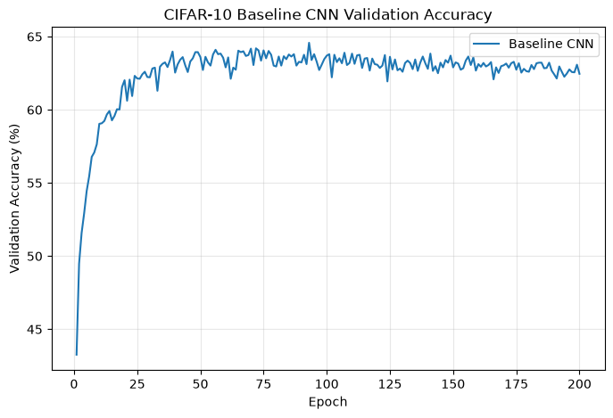

```python
epochs = range(1, len(val_accuracies) + 1)

plt.figure(figsize=(8, 5))
plt.plot(
    epochs,
    [acc * 100 for acc in val_accuracies],
    label="Baseline CNN"
)

plt.xlabel("Epoch")
plt.ylabel("Validation Accuracy (%)")
plt.title("CIFAR-10 Baseline CNN Validation Accuracy")
plt.grid(alpha=0.3)
plt.legend()
plt.show()
```

```python
baseline_train_losses = train_losses.copy()
baseline_train_accuracies = train_accuracies.copy()

baseline_val_losses = val_losses.copy()
baseline_val_accuracies = val_accuracies.copy()

print(f"Final validation accuracy: {baseline_val_accuracies[-1]:.2%}")
print(f"Best validation accuracy: {max(baseline_val_accuracies):.2%}")
print(f"Best epoch: {np.argmax(baseline_val_accuracies) + 1}")
```

```
Final validation accuracy: 62.46%
Best validation accuracy: 64.58%
Best epoch: 93
```

```python
X_train_01 = X_train.astype(np.float32) / 255.0
print(X_train_01.min(), X_train_01.max())
print(X_train_01.shape)
```

```
0.0 1.0
(45000, 32, 32, 3)
```

## Data augmentation

To experiment with the effect of data augmentation, I created 3 additional versions of each training image.

- brigher: Multiply pixel values in the range $[0,1]$ by 1.1, clipping values at 1.
- Darker: Multiply pixel values by 0.9
- Horizontally flipped: Mirror each image along the width dimension

Orignal images are also kept, giving a total of 45,000 x 4 = 180,000 training examples. All augmented versions keep their original class labels.

After augmentation, pixel values are scaled back to -1, 1

A new CNN with the same architcture, Adam optimzer, and learning rate of 0.001 is trained for 200 epochs. Both models were evaluated on the same 5,000 unmodified validation images

```python
X_original = X_train_01

X_bright = np.minimum(X_train_01 * 1.1, 1.0)

X_dark = X_train_01 * 0.9

X_flipped = np.flip(X_train_01, axis=2)
```

[figure not shown]

```python
idx = 0

fig, axes = plt.subplots(1, 4, figsize=(12, 3))

versions = [
    ("Original", X_original[idx]),
    ("Brighter", X_bright[idx]),
    ("Darker", X_dark[idx]),
    ("Flipped", X_flipped[idx])
]

for ax, (title, image) in zip(axes, versions):
    ax.imshow(image)
    ax.set_title(title)
    ax.axis("off")

plt.tight_layout()
plt.show()
```

```python
X_augmented = np.concatenate([X_original, X_bright, X_dark, X_flipped], axis=0)
y_augmented = np.concatenate([y_train, y_train, y_train, y_train], axis=0)

print("Augmented images:", X_augmented.shape)
print("Augmented labels:", y_augmented.shape)
```

```
Augmented images: (180000, 32, 32, 3)
Augmented labels: (180000,)
```

```python
X_augmented = 2.0 * X_augmented - 1.0
print(X_augmented.min(), X_augmented.max())
```

```
-1.0 1.0
```

```python
X_augmented_tensor = torch.from_numpy(X_augmented).permute(0, 3, 1, 2)
y_augmented_tensor = torch.tensor(y_augmented, dtype=torch.long)
print(X_augmented_tensor.shape)
```

```
torch.Size([180000, 3, 32, 32])
```

```python
augmented_train_dataset = TensorDataset(X_augmented_tensor, y_augmented_tensor)
augmented_train_loader = DataLoader(
    augmented_train_dataset,
    batch_size=128,
    shuffle=True,
    pin_memory=True
)
```

```python
torch.manual_seed(42)
augmented_model = CIFAR10CNN().to(device)
augmented_optimizer = torch.optim.Adam(augmented_model.parameters(), lr=0.001)
augmented_criterion = nn.CrossEntropyLoss()
```

```python
num_epochs = 200

aug_train_losses = []
aug_train_accuracies = []
aug_val_losses = []
aug_val_accuracies = []

best_val_accuracy = 0.0

for epoch in range(num_epochs):
    augmented_model.train()

    running_loss = 0.0
    correct = 0
    total = 0

    for images, labels in augmented_train_loader:
        images = images.to(device)
        labels = labels.to(device)

        augmented_optimizer.zero_grad()

        logits = augmented_model(images)
        loss = augmented_criterion(logits, labels)

        loss.backward()
        augmented_optimizer.step()

        running_loss += loss.item() * images.size(0)

        predictions = logits.argmax(dim=1)
        correct += (predictions == labels).sum().item()
        total += labels.size(0)

    aug_train_losses.append(running_loss / total)
    aug_train_accuracies.append(correct / total)

    val_loss, val_accuracy = validate_model(
        augmented_model,
        val_loader,
        augmented_criterion,
        device
    )

    aug_val_losses.append(val_loss)
    aug_val_accuracies.append(val_accuracy)

    if val_accuracy > best_val_accuracy:
        best_val_accuracy = val_accuracy

        torch.save(
            augmented_model.state_dict(),
            "cifar10_augmented_best.pt"
        )

    if (epoch + 1) % 10 == 0:
        torch.save({
            "epoch": epoch + 1,
            "model_state_dict": augmented_model.state_dict(),
            "optimizer_state_dict": augmented_optimizer.state_dict(),
            "train_losses": aug_train_losses,
            "train_accuracies": aug_train_accuracies,
            "val_losses": aug_val_losses,
            "val_accuracies": aug_val_accuracies
        }, "cifar10_augmented_checkpoint.pt")

    if (epoch + 1) % 5 == 0 or epoch == 0:
        print(
            f"Epoch {epoch+1:3d} | "
            f"Train Loss: {aug_train_losses[-1]:.4f}, "
            f"Train Acc: {aug_train_accuracies[-1]*100:.2f}% | "
            f"Val Loss: {aug_val_losses[-1]:.4f}, "
            f"Val Acc: {aug_val_accuracies[-1]*100:.2f}%"
        )
```

```
Epoch   1 | Train Loss: 1.4954, Train Acc: 45.93% | Val Loss: 1.2983, Val Acc: 53.54%
Epoch   5 | Train Loss: 1.0330, Train Acc: 64.03% | Val Loss: 1.0528, Val Acc: 63.76%
Epoch  10 | Train Loss: 0.9374, Train Acc: 67.48% | Val Loss: 1.0269, Val Acc: 63.98%
Epoch  15 | Train Loss: 0.8976, Train Acc: 68.96% | Val Loss: 0.9819, Val Acc: 65.60%
Epoch  20 | Train Loss: 0.8767, Train Acc: 69.57% | Val Loss: 0.9778, Val Acc: 66.22%
Epoch  25 | Train Loss: 0.8595, Train Acc: 70.27% | Val Loss: 0.9834, Val Acc: 65.76%
Epoch  30 | Train Loss: 0.8478, Train Acc: 70.64% | Val Loss: 0.9989, Val Acc: 64.84%
Epoch  35 | Train Loss: 0.8364, Train Acc: 70.96% | Val Loss: 0.9745, Val Acc: 66.34%
Epoch  40 | Train Loss: 0.8298, Train Acc: 71.19% | Val Loss: 0.9939, Val Acc: 65.78%
Epoch  45 | Train Loss: 0.8245, Train Acc: 71.39% | Val Loss: 0.9716, Val Acc: 66.08%
Epoch  50 | Train Loss: 0.8147, Train Acc: 71.72% | Val Loss: 0.9712, Val Acc: 66.30%
Epoch  55 | Train Loss: 0.8111, Train Acc: 71.90% | Val Loss: 1.0009, Val Acc: 65.54%
Epoch  60 | Train Loss: 0.8068, Train Acc: 72.02% | Val Loss: 0.9613, Val Acc: 66.50%
Epoch  65 | Train Loss: 0.8035, Train Acc: 72.14% | Val Loss: 0.9835, Val Acc: 66.42%
Epoch  70 | Train Loss: 0.8013, Train Acc: 72.21% | Val Loss: 0.9736, Val Acc: 66.18%
Epoch  75 | Train Loss: 0.7969, Train Acc: 72.30% | Val Loss: 0.9794, Val Acc: 66.18%
Epoch  80 | Train Loss: 0.7952, Train Acc: 72.42% | Val Loss: 0.9756, Val Acc: 66.28%
Epoch  85 | Train Loss: 0.7938, Train Acc: 72.53% | Val Loss: 0.9633, Val Acc: 66.26%
Epoch  90 | Train Loss: 0.7910, Train Acc: 72.54% | Val Loss: 0.9864, Val Acc: 66.68%
Epoch  95 | Train Loss: 0.7875, Train Acc: 72.71% | Val Loss: 0.9738, Val Acc: 66.02%
Epoch 100 | Train Loss: 0.7879, Train Acc: 72.61% | Val Loss: 1.0064, Val Acc: 65.34%
Epoch 105 | Train Loss: 0.7843, Train Acc: 72.73% | Val Loss: 0.9666, Val Acc: 66.56%
Epoch 110 | Train Loss: 0.7821, Train Acc: 72.89% | Val Loss: 0.9873, Val Acc: 66.42%
Epoch 115 | Train Loss: 0.7811, Train Acc: 72.90% | Val Loss: 0.9795, Val Acc: 66.94%
Epoch 120 | Train Loss: 0.7796, Train Acc: 72.90% | Val Loss: 0.9696, Val Acc: 66.54%
Epoch 125 | Train Loss: 0.7782, Train Acc: 72.96% | Val Loss: 0.9811, Val Acc: 66.22%
Epoch 130 | Train Loss: 0.7767, Train Acc: 72.98% | Val Loss: 0.9643, Val Acc: 66.36%
Epoch 135 | Train Loss: 0.7750, Train Acc: 73.03% | Val Loss: 0.9787, Val Acc: 66.04%
Epoch 140 | Train Loss: 0.7741, Train Acc: 73.13% | Val Loss: 0.9778, Val Acc: 66.64%
Epoch 145 | Train Loss: 0.7720, Train Acc: 73.02% | Val Loss: 0.9832, Val Acc: 66.38%
Epoch 150 | Train Loss: 0.7718, Train Acc: 73.18% | Val Loss: 0.9831, Val Acc: 66.12%
Epoch 155 | Train Loss: 0.7708, Train Acc: 73.23% | Val Loss: 0.9767, Val Acc: 66.50%
Epoch 160 | Train Loss: 0.7696, Train Acc: 73.25% | Val Loss: 0.9736, Val Acc: 66.50%
Epoch 165 | Train Loss: 0.7685, Train Acc: 73.37% | Val Loss: 0.9805, Val Acc: 66.50%
Epoch 170 | Train Loss: 0.7666, Train Acc: 73.33% | Val Loss: 0.9793, Val Acc: 66.56%
Epoch 175 | Train Loss: 0.7678, Train Acc: 73.24% | Val Loss: 0.9922, Val Acc: 66.30%
Epoch 180 | Train Loss: 0.7671, Train Acc: 73.31% | Val Loss: 0.9900, Val Acc: 65.76%
Epoch 185 | Train Loss: 0.7654, Train Acc: 73.45% | Val Loss: 1.0122, Val Acc: 66.36%
Epoch 190 | Train Loss: 0.7650, Train Acc: 73.38% | Val Loss: 0.9790, Val Acc: 66.68%
Epoch 195 | Train Loss: 0.7657, Train Acc: 73.28% | Val Loss: 0.9864, Val Acc: 66.10%
Epoch 200 | Train Loss: 0.7626, Train Acc: 73.45% | Val Loss: 1.0110, Val Acc: 66.08%
```

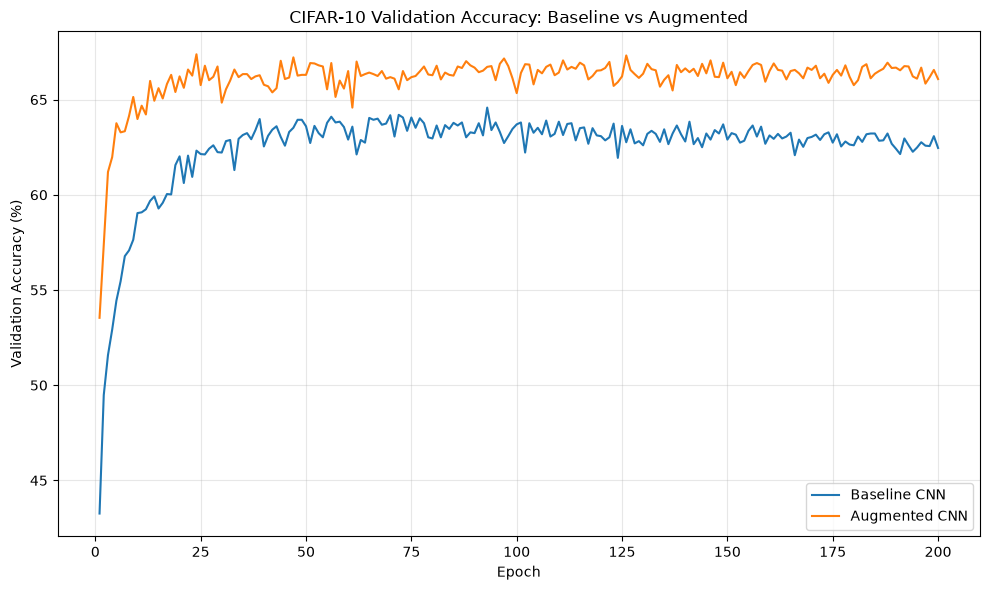

```python
plt.figure(figsize=(10, 6))

plt.plot(
    np.arange(1, len(baseline_val_accuracies) + 1),
    np.array(baseline_val_accuracies) * 100,
    label="Baseline CNN"
)

plt.plot(
    np.arange(1, len(aug_val_accuracies) + 1),
    np.array(aug_val_accuracies) * 100,
    label="Augmented CNN"
)

plt.xlabel("Epoch")
plt.ylabel("Validation Accuracy (%)")
plt.title("CIFAR-10 Validation Accuracy: Baseline vs Augmented")
plt.grid(alpha=0.3)
plt.legend()
plt.tight_layout()
plt.show()
```

```python
print(f"Baseline best: {max(baseline_val_accuracies):.2%}")
print(f"Augmented best: {max(aug_val_accuracies):.2%}")

print(f"Baseline best epoch: {np.argmax(baseline_val_accuracies) + 1}")
print(f"Augmented best epoch: {np.argmax(aug_val_accuracies) + 1}")
```

```
Baseline best: 64.58%
Augmented best: 67.38%
Baseline best epoch: 93
Augmented best epoch: 24
```

## Results

Both CNN models were trained for 200 epochs using the same architcture and optimzer settings

The augmented version maintained a higher validation accuracy throughout all of training, showing that giving the network variations in image brightness and orientation helped improve generalization

# Question 4: Self Supervised learning and transfer learning

In this problem, I experimented with self supervised pretraining to see if it could improve CIFAR 10 classification when very little labeled examples are available

I kept 500 labeled images (50 per class) for the original 10 class classification task. The ramining are used for self supervised pretraining without the original class lables.

A three class pretext classification task is created with the following transformations

- Class 0: Orignal image
- Class 1: Image flipped vertically
- Class 2: Image rotated 90 degrees counter clockwise

```python
rng = np.random.default_rng(seed=42)

labeled_indices = []

for class_id in range(10):
    class_indices = np.where(y == class_id)[0]
    selected = rng.choice(class_indices, size=50, replace=False)
    labeled_indices.extend(selected)

labeled_indices = np.array(labeled_indices)

unlabeled_indices = np.setdiff1d(np.arange(len(X)), labeled_indices)

X_labeled = X[labeled_indices]
y_labeled = y[labeled_indices]

X_unlabeled = X[unlabeled_indices]

print("labeled images:", X_labeled.shape)
print("labeled class counts:", np.bincount(y_labeled))
print("unlabeled images:", X_unlabeled.shape)
```

```
labeled images: (500, 32, 32, 3)
labeled class counts: [50 50 50 50 50 50 50 50 50 50]
unlabeled images: (49500, 32, 32, 3)
```

```python
X_class0 = X_unlabeled
X_class1 = np.flip(X_unlabeled, axis=1)
X_class2 = np.rot90(X_unlabeled, k=1, axes=(1, 2))
```

```python
X_pretext = np.concatenate([X_class0, X_class1, X_class2], axis=0)
y_pretext = np.concatenate([
    np.zeros(len(X_class0), dtype=np.int64),
    np.ones(len(X_class1), dtype=np.int64),
    np.full(len(X_class2), 2, dtype=np.int64)
])

print("pretext images:", X_pretext.shape)
print("pretext labels:", y_pretext.shape)
print("class counts:", np.bincount(y_pretext))
```

```
pretext images: (148500, 32, 32, 3)
pretext labels: (148500,)
class counts: [49500 49500 49500]
```

```python
X_pretext_scaled = 2.0 * (X_pretext.astype(np.float32) / 255.0) - 1.0
X_pretext_tensor = torch.from_numpy(X_pretext_scaled).permute(0, 3, 1, 2)
y_pretext_tensor = torch.from_numpy(y_pretext)

print("Input shape:", X_pretext_tensor.shape)
print("Label shape:", y_pretext_tensor.shape)
print("Pixel range:",
      X_pretext_tensor.min().item(),
      X_pretext_tensor.max().item())
```

```
Input shape: torch.Size([148500, 3, 32, 32])
Label shape: torch.Size([148500])
Pixel range: -1.0 1.0
```

```python
pretext_dataset = TensorDataset(X_pretext_tensor, y_pretext_tensor)
pretext_loader = DataLoader(
    pretext_dataset,
    batch_size=128,
    shuffle=True,
    pin_memory=True
)
```

```python
class CIFAR10CNN_P4(nn.Module):
    def __init__(self, num_classes=10):
        super().__init__()

        self.network = nn.Sequential(
            nn.Conv2d(3, 10, kernel_size=5, stride=1, padding=0),
            nn.ReLU(),
            nn.MaxPool2d(kernel_size=2, stride=2),

            nn.Conv2d(10, 10, kernel_size=5, stride=1, padding=0),
            nn.ReLU(),
            nn.MaxPool2d(kernel_size=2, stride=2),

            nn.Flatten(),
            nn.Linear(250, 20),
            nn.ReLU(),
            nn.Linear(20, num_classes)
        )

        # He initialization
        for layer in self.network:
            if isinstance(layer, (nn.Conv2d, nn.Linear)):
                nn.init.kaiming_normal_(
                    layer.weight,
                    mode="fan_in",
                    nonlinearity="relu"
                )
                nn.init.zeros_(layer.bias)

    def forward(self, x):
        return self.network(x)
```

## Pretext Model

```python
torch.manual_seed(42)
pretext_model = CIFAR10CNN_P4(num_classes=3).to(device)
pretext_optimizer = torch.optim.Adam(
    pretext_model.parameters(),
    lr = 0.001
)
pretext_criterion = nn.CrossEntropyLoss()
```

```python
num_epochs = 100
pretext_losses = []
pretext_accuracies = []

for epoch in range(num_epochs):
    pretext_model.train()

    running_loss = 0.0
    correct = 0
    total = 0

    for images, labels in pretext_loader:
        images = images.to(device)
        labels = labels.to(device)

        pretext_optimizer.zero_grad()

        logits = pretext_model(images)
        loss = pretext_criterion(logits, labels)

        loss.backward()
        pretext_optimizer.step()

        running_loss += loss.item() * images.size(0)

        predictions = logits.argmax(dim = 1)
        correct += (predictions ==  labels).sum().item()
        total += labels.size(0)

    pretext_losses.append(running_loss / total)
    pretext_accuracies.append(correct / total)

    if (epoch + 1) % 10 == 0 or epoch == 0:
        print(
            f"Epoch {epoch+1:3d} | "
            f"Train Loss: {pretext_losses[-1]:.4f} | "
            f"Train Accuracy: {pretext_accuracies[-1]:.2%}"
        )

    if (epoch + 1) % 10 == 0:
        torch.save({
            "epoch": epoch + 1,
            "model_state_dict": pretext_model.state_dict(),
            "optimizer_state_dict": pretext_optimizer.state_dict(),
            "train_losses": pretext_losses,
            "train_accuracies": pretext_accuracies
        }, "pretext_checkpoint.pt")
```

```
Epoch   1 | Train Loss: 0.8448 | Train Accuracy: 60.11%
Epoch  10 | Train Loss: 0.6135 | Train Accuracy: 73.55%
Epoch  20 | Train Loss: 0.5742 | Train Accuracy: 75.65%
Epoch  30 | Train Loss: 0.5547 | Train Accuracy: 76.47%
Epoch  40 | Train Loss: 0.5449 | Train Accuracy: 76.99%
Epoch  50 | Train Loss: 0.5360 | Train Accuracy: 77.46%
Epoch  60 | Train Loss: 0.5295 | Train Accuracy: 77.75%
Epoch  70 | Train Loss: 0.5274 | Train Accuracy: 77.81%
Epoch  80 | Train Loss: 0.5220 | Train Accuracy: 78.10%
Epoch  90 | Train Loss: 0.5188 | Train Accuracy: 78.29%
Epoch 100 | Train Loss: 0.5162 | Train Accuracy: 78.39%
```

```python
torch.save(pretext_model.state_dict(), "pretext_model.pt")
```

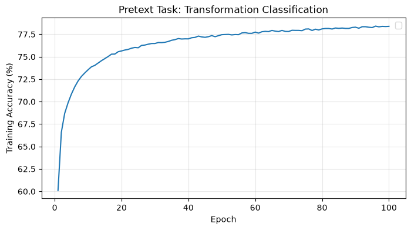

```python
plt.figure(figsize=(8, 4))
plt.plot(
    range(1, len(pretext_accuracies) + 1),
    [acc * 100 for acc in pretext_accuracies]
)

plt.xlabel("Epoch")
plt.ylabel("Training Accuracy (%)")
plt.title("Pretext Task: Transformation Classification")
plt.legend()
plt.grid(alpha=0.3)
plt.show()
```

## Baseline Model

```python
X_small_scaled = (2.0 * (X_labeled.astype(np.float32) / 255.0) - 1.0)
X_small_tensor = torch.from_numpy(X_small_scaled).permute(0, 3, 1, 2)
y_small_tensor = torch.tensor(y_labeled, dtype=torch.long)

print("Input shape:", X_small_tensor.shape)
print("Label shape:", y_small_tensor.shape)
```

```
Input shape: torch.Size([500, 3, 32, 32])
Label shape: torch.Size([500])
```

```python
test_data = CIFAR10(root="./data", train=False, download=True)
X_test = test_data.data
y_test = np.array(test_data.targets)
X_test_scaled = (2.0 * (X_test.astype(np.float32) / 255.0) - 1.0)
X_test_tensor = torch.from_numpy(X_test_scaled).permute(0, 3, 1, 2)
y_test_tensor = torch.tensor(y_test, dtype=torch.long)

print("Test images:", X_test_tensor.shape)
```

```
Test images: torch.Size([10000, 3, 32, 32])
```

```python
small_dataset = TensorDataset(X_small_tensor, y_small_tensor)
small_loader = DataLoader(
    small_dataset,
    batch_size=128,
    shuffle=True,
    pin_memory=True
)

test_dataset = TensorDataset(X_test_tensor, y_test_tensor)
test_loader = DataLoader(
    test_dataset,
    batch_size=256,
    shuffle=False,
    pin_memory=True
)
```

```python
torch.manual_seed(42)
small_baseline_model = CIFAR10CNN_P4(num_classes=10).to(device)
small_baseline_optimizer = torch.optim.Adam(
    small_baseline_model.parameters(),
    lr = 0.001
)
small_baseline_criterion = nn.CrossEntropyLoss()
```

```python
num_epochs = 10000

baseline_test_accuracies = []
baseline_eval_epochs = []

for epoch in range(num_epochs):
    small_baseline_model.train()

    for images, labels in small_loader:
        images = images.to(device)
        labels = labels.to(device)

        small_baseline_optimizer.zero_grad()

        logits = small_baseline_model(images)
        loss = small_baseline_criterion(logits, labels)

        loss.backward()
        small_baseline_optimizer.step()

    if (epoch + 1) % 100 == 0:
        test_loss, test_accuracy = validate_model(small_baseline_model, test_loader, small_baseline_criterion, device)
        baseline_eval_epochs.append(epoch + 1)
        baseline_test_accuracies.append(test_accuracy)

        print(f"Epoch {epoch+1:5d} | "
              f"Test Accuracy {test_accuracy:.2%}"
        )

    if (epoch + 1) % 500 == 0:
        torch.save({
            "epoch": epoch + 1,
            "model_state_dict": small_baseline_model.state_dict(),
            "optimizer_state_dict": small_baseline_optimizer.state_dict(),
            "eval_epochs": baseline_eval_epochs,
            "test_accuracies": baseline_test_accuracies
        }, "small_baseline_checkpoint.pt")
```

```
Epoch   100 | Test Accuracy 30.87%
Epoch   200 | Test Accuracy 30.40%
Epoch   300 | Test Accuracy 30.44%
Epoch   400 | Test Accuracy 30.52%
Epoch   500 | Test Accuracy 30.32%
Epoch   600 | Test Accuracy 30.26%
Epoch   700 | Test Accuracy 30.31%
Epoch   800 | Test Accuracy 30.40%
Epoch   900 | Test Accuracy 30.40%
Epoch  1000 | Test Accuracy 30.52%
Epoch  1100 | Test Accuracy 30.52%
Epoch  1200 | Test Accuracy 30.48%
Epoch  1300 | Test Accuracy 30.53%
Epoch  1400 | Test Accuracy 30.53%
Epoch  1500 | Test Accuracy 30.44%
Epoch  1600 | Test Accuracy 30.47%
Epoch  1700 | Test Accuracy 30.43%
Epoch  1800 | Test Accuracy 30.41%
Epoch  1900 | Test Accuracy 30.38%
Epoch  2000 | Test Accuracy 30.34%
Epoch  2100 | Test Accuracy 30.31%
Epoch  2200 | Test Accuracy 30.31%
Epoch  2300 | Test Accuracy 30.33%
Epoch  2400 | Test Accuracy 30.32%
Epoch  2500 | Test Accuracy 30.28%
Epoch  2600 | Test Accuracy 30.29%
Epoch  2700 | Test Accuracy 30.32%
Epoch  2800 | Test Accuracy 30.35%
Epoch  2900 | Test Accuracy 30.35%
Epoch  3000 | Test Accuracy 30.32%
Epoch  3100 | Test Accuracy 30.34%
Epoch  3200 | Test Accuracy 30.31%
Epoch  3300 | Test Accuracy 30.26%
Epoch  3400 | Test Accuracy 30.23%
Epoch  3500 | Test Accuracy 30.19%
Epoch  3600 | Test Accuracy 30.21%
Epoch  3700 | Test Accuracy 30.13%
Epoch  3800 | Test Accuracy 30.12%
Epoch  3900 | Test Accuracy 30.11%
Epoch  4000 | Test Accuracy 30.11%
```

[output cut: 45 more lines]

```
Epoch  8600 | Test Accuracy 29.51%
Epoch  8700 | Test Accuracy 29.54%
Epoch  8800 | Test Accuracy 29.51%
Epoch  8900 | Test Accuracy 29.56%
Epoch  9000 | Test Accuracy 29.59%
Epoch  9100 | Test Accuracy 29.62%
Epoch  9200 | Test Accuracy 29.64%
Epoch  9300 | Test Accuracy 29.67%
Epoch  9400 | Test Accuracy 29.63%
Epoch  9500 | Test Accuracy 29.67%
Epoch  9600 | Test Accuracy 29.65%
Epoch  9700 | Test Accuracy 29.64%
Epoch  9800 | Test Accuracy 29.52%
Epoch  9900 | Test Accuracy 29.46%
Epoch 10000 | Test Accuracy 29.45%
```

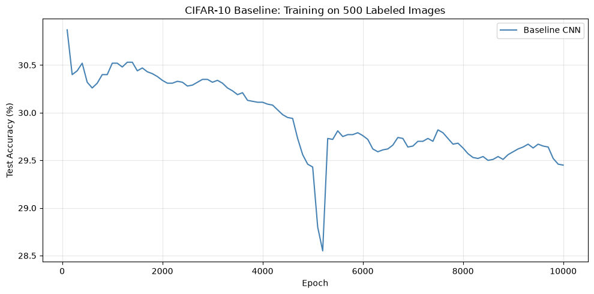

```python
plt.figure(figsize=(10, 5))

plt.plot(
    baseline_eval_epochs,
    np.array(baseline_test_accuracies) * 100,
    label="Baseline CNN",
    color="steelblue"
)

plt.xlabel("Epoch")
plt.ylabel("Test Accuracy (%)")
plt.title("CIFAR-10 Baseline: Training on 500 Labeled Images")
plt.grid(alpha=0.3)
plt.legend()
plt.tight_layout()
plt.show()
```

## Baseline and transfer learning

Two CNN classifiers are trained on the same 500 labeled CIFAR 10 imaegs

Baseline: A CNN is trained from scratch using He initialization and Adam optimzation with a learning rate of 0.001

Transfer learning: A second CNN is initialized using the weights learned during the self superivsed pretext task. All pretrained layers are transferred expect the final classification layer, since the pretext network predicts 3 classes while the original CIFAR 10 task needs 10

The final layer is initialized with He initailzaiton

The preserve the previously learned visual features, the transferred layers use a smaller learning rate of 0.00001 with the newly initialzed layer used 0.001

Both models were trained with 10,000 epochs. Accuracy is evaluated every 100

```python
pretext_weights = torch.load("pretext_model.pt", map_location=device, weights_only=True)
print(pretext_weights.keys())
```

```
odict_keys(['network.0.weight', 'network.0.bias', 'network.3.weight', 'network.3.bias', 'network.7.weight', 'network.7.bias', 'network.9.weight', 'network.9.bias'])
```

```python
torch.manual_seed(42)
transfer_model = CIFAR10CNN_P4(num_classes=10).to(device)

transfer_weights = {
    name: weights
    for name, weights in pretext_weights.items()
    if not name.startswith("network.9.")
}

transfer_model.load_state_dict(transfer_weights, strict=False)
```

```
_IncompatibleKeys(missing_keys=['network.9.weight', 'network.9.bias'], unexpected_keys=[])
```

```python
transfer_optimizer = torch.optim.Adam([
    {'params': transfer_model.network[:9].parameters(), 'lr': 1e-5},
    {'params': transfer_model.network[9].parameters(), 'lr': 1e-3}
])
transfer_criterion = nn.CrossEntropyLoss()
```

```python
num_epochs = 10000

transfer_test_accuracies = []
transfer_eval_epochs = []

for epoch in range(num_epochs):
    transfer_model.train()

    for images, labels in small_loader:
        images = images.to(device)
        labels = labels.to(device)

        transfer_optimizer.zero_grad()

        logits = transfer_model(images)
        loss = transfer_criterion(logits, labels)

        loss.backward()
        transfer_optimizer.step()

    if (epoch + 1) % 100 == 0:
        test_loss, test_accuracy = validate_model(transfer_model, test_loader, transfer_criterion, device)
        transfer_eval_epochs.append(epoch + 1)
        transfer_test_accuracies.append(test_accuracy)

        print(f"Epoch {epoch+1:5d} | "
              f"Test Accuracy {test_accuracy:.2%}"
        )

    if (epoch + 1) % 500 == 0:
        torch.save({
            "epoch": epoch + 1,
            "model_state_dict": transfer_model.state_dict(),
            "optimizer_state_dict": transfer_optimizer.state_dict(),
            "eval_epochs": transfer_eval_epochs,
            "test_accuracies": transfer_test_accuracies
        }, "small_transfer_checkpoint.pt")
```

```
Epoch   100 | Test Accuracy 17.31%
Epoch   200 | Test Accuracy 28.48%
Epoch   300 | Test Accuracy 31.01%
Epoch   400 | Test Accuracy 32.00%
Epoch   500 | Test Accuracy 32.51%
Epoch   600 | Test Accuracy 32.89%
Epoch   700 | Test Accuracy 32.91%
Epoch   800 | Test Accuracy 33.10%
Epoch   900 | Test Accuracy 33.23%
Epoch  1000 | Test Accuracy 33.33%
Epoch  1100 | Test Accuracy 33.17%
Epoch  1200 | Test Accuracy 33.00%
Epoch  1300 | Test Accuracy 32.84%
Epoch  1400 | Test Accuracy 32.93%
Epoch  1500 | Test Accuracy 32.82%
Epoch  1600 | Test Accuracy 32.81%
Epoch  1700 | Test Accuracy 32.94%
Epoch  1800 | Test Accuracy 32.87%
Epoch  1900 | Test Accuracy 32.92%
Epoch  2000 | Test Accuracy 33.01%
Epoch  2100 | Test Accuracy 32.90%
Epoch  2200 | Test Accuracy 32.86%
Epoch  2300 | Test Accuracy 32.91%
Epoch  2400 | Test Accuracy 32.59%
Epoch  2500 | Test Accuracy 32.36%
Epoch  2600 | Test Accuracy 32.27%
Epoch  2700 | Test Accuracy 32.01%
Epoch  2800 | Test Accuracy 31.96%
Epoch  2900 | Test Accuracy 31.89%
Epoch  3000 | Test Accuracy 31.87%
Epoch  3100 | Test Accuracy 31.76%
Epoch  3200 | Test Accuracy 31.65%
Epoch  3300 | Test Accuracy 31.55%
Epoch  3400 | Test Accuracy 31.39%
Epoch  3500 | Test Accuracy 31.48%
Epoch  3600 | Test Accuracy 31.41%
Epoch  3700 | Test Accuracy 31.28%
Epoch  3800 | Test Accuracy 31.38%
Epoch  3900 | Test Accuracy 31.27%
Epoch  4000 | Test Accuracy 31.20%
```

[output cut: 45 more lines]

```
Epoch  8600 | Test Accuracy 31.21%
Epoch  8700 | Test Accuracy 31.20%
Epoch  8800 | Test Accuracy 31.16%
Epoch  8900 | Test Accuracy 31.18%
Epoch  9000 | Test Accuracy 31.20%
Epoch  9100 | Test Accuracy 31.18%
Epoch  9200 | Test Accuracy 31.14%
Epoch  9300 | Test Accuracy 31.08%
Epoch  9400 | Test Accuracy 31.10%
Epoch  9500 | Test Accuracy 31.10%
Epoch  9600 | Test Accuracy 31.08%
Epoch  9700 | Test Accuracy 31.06%
Epoch  9800 | Test Accuracy 31.09%
Epoch  9900 | Test Accuracy 31.10%
Epoch 10000 | Test Accuracy 31.11%
```

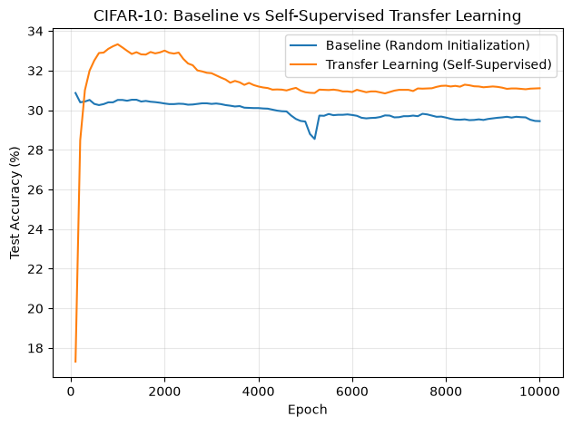

```python
plt.plot(
    baseline_eval_epochs,
    [acc * 100 for acc in baseline_test_accuracies],
    label="Baseline (Random Initialization)"
)

plt.plot(
    transfer_eval_epochs,
    [acc * 100 for acc in transfer_test_accuracies],
    label="Transfer Learning (Self-Supervised)"
)

plt.xlabel("Epoch")
plt.ylabel("Test Accuracy (%)")
plt.title("CIFAR-10: Baseline vs Self-Supervised Transfer Learning")
plt.legend()
plt.grid(alpha=0.3)
plt.tight_layout()
plt.show()
```

## Results

The resutls show that the visual features learned during self supervised pretraining provided a useful starting point for the original classifcation task, improving genrealization when label training data was limited.